# Week 2 Assignment

Jerri Berry Danso

February 3, 2025

For this assignment, we are going to use data from the National Assessment of Educational Progress (NAEP), or the “Nation’s Report Card.” The data here is for the 4th grade mathematics test. You can read more about it here: https://www.nationsreportcard.gov/

The NAEP is an important data source in education; read some recent coverage of scores (post-pandemic) here in USA Today: https://www.usatoday.com/story/news/education/2023/06/21/naep-scores-basic-reading-math-13-year-olds/70337312007/

## Step 1

Load necessary packages (you may need to install these packages first using `install.packages("___")`): rmarkdown, tidyverse, janitor, and skimr. Do so in the code chunk below. Be sure to comment (add a `#` as the first character) these lines after you have installed the packages; otherwise, R Markdown may run into issues when you try to knit the file.

```r
# Install packages below
# Packages were already installed, so I loaded them instead
library(rmarkdown)
library(tidyverse)
library(janitor)
library(skimr)
```

## Step 2

Load in data. *Notes*: you must assign a name to the dataframe before loading it. Ensure that the data is saved *in the same folder* as this file is saved.

```r
NAEP_data <- read_csv("naep-data.csv")
```

## Step 3

View your data. There are multiple ways to do this. Here are two options, with some code to get you started.

```r
glimpse(NAEP_data )
```

```
## Rows: 51
## Columns: 4
## $ Jurisdiction               <chr> "Wyoming", "Massachusetts", "Nebraska", "Fl…
## $ `Average Score (0 - 500)`  <dbl> 243, 242, 242, 241, 240, 240, 240, 240, 239…
## $ `At or Above Basic %`      <dbl> 84, 79, 80, 81, 79, 81, 80, 78, 80, 77, 78,…
## $ `At or Above Proficient %` <dbl> 44, 43, 43, 41, 43, 40, 40, 42, 40, 39, 40,…
```

```r
view(NAEP_data )
summary(NAEP_data)
```

```
##  Jurisdiction       Average Score (0 - 500) At or Above Basic %
##  Length:51          Min.   :221.0           Min.   :57.00
##  Class :character   1st Qu.:230.0           1st Qu.:70.50
##  Mode  :character   Median :235.0           Median :75.00
##                     Mean   :234.4           Mean   :73.69
##                     3rd Qu.:239.0           3rd Qu.:78.00
##                     Max.   :243.0           Max.   :84.00
##  At or Above Proficient %
##  Min.   :19.00
##  1st Qu.:30.50
##  Median :35.00
##  Mean   :34.53
##  3rd Qu.:40.00
##  Max.   :44.00
```

## Step 4

Clean variable names using the janitor package. You’ll need to use the assignment operator to ensure your clean names save to a dataframe. You might consider using a name that includes the phrase “clean” to clarify to you and others what the difference is!

Before doing so, take a peak at some of the handy functions that janitor provides, focusing on the `clean_names()` example: https://cran.r-project.org/web/packages/janitor/vignettes/janitor.html

```r
NAEP_data_clean <- NAEP_data %>%
  clean_names()
```

## Step 5

Find the mean, standard deviation, quartiles, and more with the `skim()` function and the name of your data frame. Please first read a bit about skimr - how it works and what its benefits are - here: https://cloud.r-project.org/web/packages/skimr/vignettes/skimr.html

```r
NAEP_data_clean %>%
  skim()
```

Data summary

| Name | Piped data |
| --- | --- |
| Number of rows | 51 |
| Number of columns | 4 |
| _______________________ |  |
| Column type frequency: |  |
| character | 1 |
| numeric | 3 |
| ________________________ |  |
| Group variables | None |

**Variable type: character**

| skim_variable | n_missing | complete_rate | min | max | empty | n_unique | whitespace |
| --- | --- | --- | --- | --- | --- | --- | --- |
| jurisdiction | 0 | 1 | 4 | 20 | 0 | 51 | 0 |

**Variable type: numeric**

| skim_variable | n_missing | complete_rate | mean | sd | p0 | p25 | p50 | p75 | p100 | hist |
| --- | --- | --- | --- | --- | --- | --- | --- | --- | --- | --- |
| average_score_0_500 | 0 | 1 | 234.35 | 5.28 | 221 | 230.0 | 235 | 239 | 243 | ▁▅▆▇▇ |
| at_or_above_basic_percent | 0 | 1 | 73.69 | 5.70 | 57 | 70.5 | 75 | 78 | 84 | ▁▂▂▇▃ |
| at_or_above_proficient_percent | 0 | 1 | 34.53 | 5.89 | 19 | 30.5 | 35 | 40 | 44 | ▂▅▇▇▇ |

Congrats! You’re on your way to exploring an authentic data set in R. Onto some questions:

## Step 6 (Reach)

Here’s one optional step. Create a plot using either *base R* or *ggplot2*. Use the code chunk below and add a bullet point or two interpreting your plot below the code you used to create it.

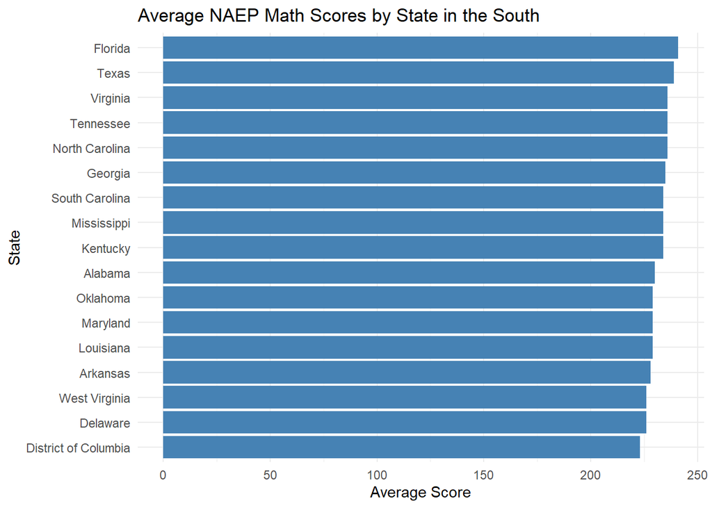

```r
#Bar graph to illustrate average scores for states in the South

#identify states in the South

southern_states <- c("Delaware", "Florida", "Georgia", "Maryland",
                     "North Carolina", "South Carolina", "Virginia",
                     "West Virginia", "District of Columbia",
                     "Alabama", "Kentucky", "Mississippi", "Tennessee",
                     "Arkansas", "Louisiana", "Oklahoma", "Texas")

#Filter data for states in the south
NAEP_south <- NAEP_data_clean %>%
  filter(jurisdiction %in% southern_states)

#Simple graph showing average scores in Southern States
ggplot(NAEP_south, aes(x = reorder(jurisdiction, average_score_0_500), y = average_score_0_500)) +
  geom_bar(stat = "identity", fill = "steelblue") +
  coord_flip() +
  labs(title = "Average NAEP Math Scores by State in the South",
       x = "State",
       y = "Average Score") +
  theme_minimal()
```

Florida has the highest average score (241) of all the states in the South. The District of Columbia has the lowest average score (223) of all the states in the South.

```r
#Answers to questions

# #1 Average score of the nation
mean(NAEP_data_clean$average_score_0_500, na.rm = TRUE)
```

```
## [1] 234.3529
```

```r
# #2 Average score for your home state (Florida)

NAEP_data_clean %>%
  filter(jurisdiction == "Florida") %>%
  pull(average_score_0_500)
```

```
## [1] 241
```

```r
# #3 Home state and the nation comparison with average scores

241 - 234.3529
```

```
## [1] 6.6471
```

```r
# #4 State with maximum and minimum average score

NAEP_data_clean %>%
  filter(average_score_0_500 == max(average_score_0_500, na.rm = TRUE)) %>%
  select(jurisdiction, average_score_0_500)
```

```
## # A tibble: 1 × 2
##   jurisdiction average_score_0_500
##   <chr>                      <dbl>
## 1 Wyoming                      243
```

```r
NAEP_data_clean %>%
  filter(average_score_0_500 == min(average_score_0_500, na.rm = TRUE)) %>%
  select(jurisdiction, average_score_0_500)
```

```
## # A tibble: 1 × 2
##   jurisdiction average_score_0_500
##   <chr>                      <dbl>
## 1 New Mexico                   221
```

## Rubric

|  | Points Possible | Points Earned |
| --- | --- | --- |
| File knits | 5 |  |
| Code is appropriate | 5 |  |
| Question 1 answered | 5 |  |
| Question 2 answered | 5 |  |
| Question 3 answered | 5 |  |
| Question 4 answered | 5 |  |

## Knit and Submit

Complete the following steps to knit and publish your work:

1. First, change the name of the `author:` in the [YAML header](https://bookdown.org/yihui/rmarkdown-cookbook/rmarkdown-anatomy.html#yaml-metadata) at the very top of this document to your name. The YAML header controls the style and feel for knitted document but doesn’t actually display in the final output.
2. Next, click the knit button in the toolbar above to “knit” your R Markdown document to a [HTML](https://bookdown.org/yihui/rmarkdown/html-document.html) file that will be saved in your R Project folder. You should see a formatted webpage appear in your Viewer tab in the lower right pan or in a new browser window. Let’s us know if you run into any issues with knitting.
3. Upload the HTML file that is now present in the same folder as this R Markdown file to Canvas to receive credit for this assignment!